# Comparing Suicide Statistics for Males and Females Between the United States and Canada from 1985-2016

Bethany Lucey

```r
library(tidyverse)
library(kableExtra)
library(ggrepel)
library(scales)
#load more packages here as necessary
```

```r
#Import the Data
suicides <-  read.csv('suicides.csv')
```

```r
 suicides <- suicides %>%
  drop_na() %>%
distinct()
```

```r
 suicides_US_CA <- suicides %>%
  filter(country == "United States"| country =="Canada")
```

# Introduction

How do suicide rates vary by country? By sex? By culture? Data collected on suicides rates in different countries between 1985 to 2016 can be used to help answer this question and prevent suicides. Canada and the United States are comparable counties. They are of similar size, location and climate. Performing a data analysis will enable us to learn more about data patterns regarding suicide in the respective countries. This analysis will provide insight into the cultures in each country, specifically regarding mental health. For example, do higher suicide rates reflect flaws in culture?

In this analysis the variables country (US and Canada),year, and sex will be compared to tackle the research question: how do suicide rates vary between the United States and Canada and within each respective nation how do the rates vary by sex? As an overview, we will first look at the data for the United States and Canada compared to the variable “year” in order to observe if there are any similarities or differences in the trends of suicide rates over time. Then we will look further into how males and females in each respective country are affected by suicide.I predict that there will be a higher prevalence of suicides in the United States and specifically, women in the United States will commit suicide at higher rates than any other category.

# Results

```r
 suicides_US_CA %>%
  group_by(country,sex) %>%
    summarise(total_suicides_100k= sum(suicides.100k.pop),
              average_suicides.100k.pop = mean(suicides.100k.pop),
               median_number_of_suicides_100k = median(suicides.100k.pop),
              standard_deviation_suicides.100k.pop= sd(suicides.100k.pop)) %>%
    kbl(digits=5,
      col.names=c("Country","Sex", "Total Suicides", "Average Number of Suicides", "Median Number of Suicides","Standard Deviation of Suicides"),
      caption= "Comparing Suicide Statistics per 100k people in the United States and Canada by Sex")%>%
    kable_styling()
```

Comparing Suicide Statistics per 100k people in the United States and Canada by Sex

| Country | Sex | Total Suicides | Average Number of Suicides | Median Number of Suicides | Standard Deviation of Suicides |
| --- | --- | --- | --- | --- | --- |
| Canada | female | 273.95 | 5.07315 | 5.485 | 2.35038 |
| Canada | male | 1012.55 | 18.75093 | 21.420 | 9.00120 |
| United States | female | 290.59 | 4.84317 | 4.975 | 2.51600 |
| United States | male | 1372.67 | 22.87783 | 23.645 | 12.87472 |

This table provides summary statistics for suicides rates for the United States and Canada broken down by sex. It is clear that more people commit suicides in the United States compared to Canada by looking at the Total Suicide per 100k column. Males in both countries have a higher median, total, and average number of suicides per 100k people compared to females. The median number of suicides per 100k people for females in Canada is 5.485 and slightly lower at 4.975 for the females in the United States. The median for males in Canada is 21.420 and the median for males in the United States is larger at 23.645. The standard deviation is around 9 for Canadian men and about 12.87 for american men, indicating that in both cases there is a large spread in the data (the values are further from the mean).

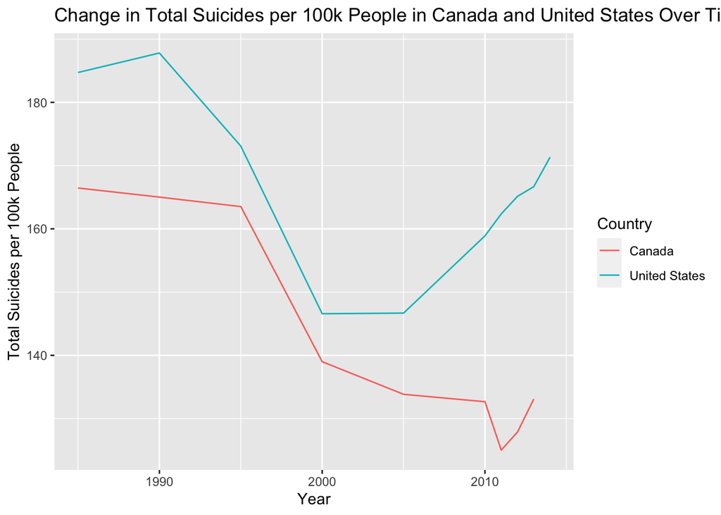

```r
   suicides_US_CA %>%
  group_by(year,country)%>%
  summarise(count=sum(suicides.100k.pop)) %>%
  ggplot(aes(x=year,y=count,color=country))+
  geom_line()+
  labs(colour="Country")+
  xlab("Year")+
  ylab("Total Suicides per 100k People")+
  ggtitle("Change in Total Suicides per 100k People in Canada and United States Over Time")+
  theme_gray()
```

This line chart displays the total suicides per 100k people over the years 1985-2016. Throughout the time period, the United States has more total suicides per 100k people than Canada, as the United States line lies above the Canadian line and the two lines never intersect. For both countries, the graphs slopes change from negative to positive or plateau along similar time intervals. Towards the end of the time interval, the two countries diverge slightly in their trends, but it looks like the Canada line begins to spike back up, mirroring the United States.

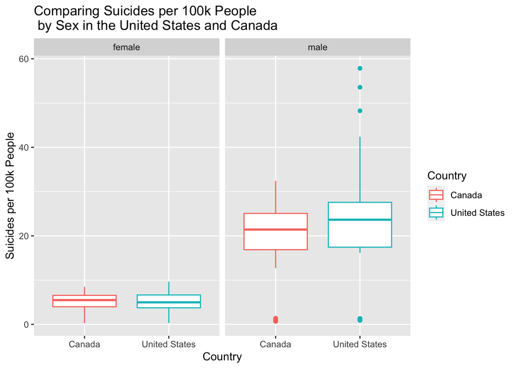

```r
    suicides_US_CA %>%
   ggplot(aes(x=country,y=suicides.100k.pop,color=country))+
   geom_boxplot()+
   facet_wrap(~ sex, nrow = 1)+
       labs(colour="Country")+
  xlab("Country")+
  ylab("Suicides per 100k People")+
  ggtitle("Comparing Suicides per 100k People \n by Sex in the United States and Canada")+
  theme_gray()
```

This series of box plots displays a side by side comparison of the suicides per 100k people broken down by both country and sex. The proportions are very different between groups in this standardized box plot. Specifically, men in both the United States and Canada commit suicide at significantly higher rates then women. For men, the United states median is slightly higher than the Canadian and for women, the opposite is true. For males in both countries, the IQR range is significantly larger, indicating a larger spread in the data.

# Discussion

The results from the line chart show that the suicide rate for both countries rise and fall during similar windows of time. This could mean that both Canadians and Americans are being affected by world events similarly and likely have similar cultures or potentially similar approaches to mental health.

The results show that the United States has an overall higher prevalence of suicide.These results indicate that more work to emphasis the importance of mental health could be helpful to create cultural changes and thus, hopefully decrease the total number of suicides in the United States. Collecting further data on suicide in the United States could help to provide more insights.

The results from the side by side box plot as well as the table, disprove the hypothesis that american women will have higher rates of suicide. Instead, the results indicate that in both countries, there is likely a cultural issue surrounding men and mental health. Why are men committing suicide at glaringly higher rates than females? A higher prevalence of suicide is likely a reflection of culture. There is more stigma regarding mental health around men compared to women. These findings indicate that more effort needs to be made to weaken the stigma around mental health for men and help to decrease the prevalence of male suicides in the United States and Canada. As previously mentioned, if suicide rates in both countries have historically followed similar patterns, then efforts to help men in the United States could also be potentially applied to the context of Canadian men as well. Collecting more detailed data that is specific to men in both countries could help to provide more insights into the causes of suicide in the respective male populations. The more data available, the more analysis that can be done and thus, hopefully the more actions that can be taken in order to prevent suicides in the future.

# References

Suicides Rate Overview 1985 to 2016. (2019). https://www.kaggle.com/datasets/russellyates88/suicide-rates-overview-1985-to-2016